# Research: Free Speech and Inclusion

research design

analysis

dataviz

Published

September 23, 2023

[figure not shown]

How do college students think about free speech, cancel culture, and ideological expression? This study, conducted in partnership with the [Constructive Dialogue Institute](https://constructivedialogue.org), set out to answer those questions with a national survey of 2,618 college students.

As a research fellow at More in Common, I contributed to the design and analysis of this study. The survey measured attitudes toward free speech and social inclusion, experiences of being offended or called out, and students’ political self-identification.

## Three takeaways

- Most students support open discourse in principle: 94% said it’s important to listen to others with an open mind. But, nearly half (45%) have held back their own opinions in class, fearing they’d offend someone.
- Fear of speaking up crosses political lines. Conservatives feel it most sharply, but students on the left report it too, suggesting this isn’t simply a story about one side silencing the other.
- Social Justice Orientation predicts a lot. Liberal and conservative students diverge sharply on social justice beliefs, and those beliefs connect to a wide range of other attitudes and behaviors.

Beyond the public-facing report, I ran deeper exploratory analyses examining how Social Justice Orientation relates to other student attitudes. The visualizations below are from that work.

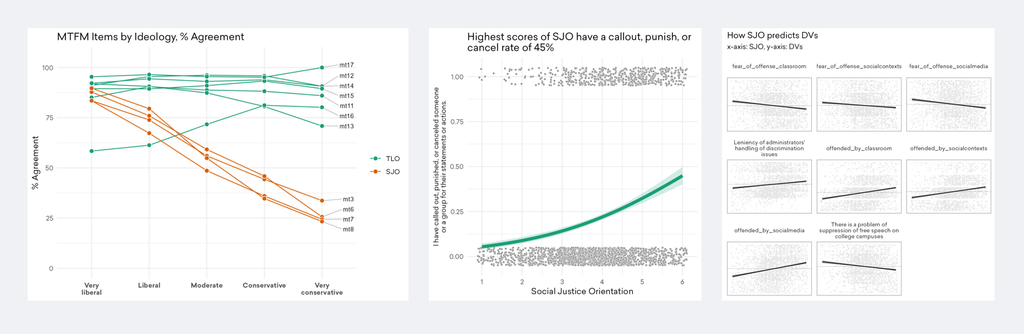

## Tools

R · Qualtrics Panels · Qualtrics Survey Design · Asana · Slack

## Read More

- [Read the full report](https://www.moreincommon.com/media/dxrh2mjs/annual-survey-report_9-19-23-1.pdf)
- [Read a More in Common newsletter summary of the report](https://moreincommon.substack.com/p/are-free-speech-and-inclusion-at)